# Lab 4 - Hidden Markov Models

Liz Elmstrom, Terrance Wang, Emma Timmins-Schiffman

May 9, 2023

# General Questions

As part of the California Current Integrated Ecosystem Report, NOAA scientists do annual updates of [stoplight charts for ecosystem indicators](https://www.fisheries.noaa.gov/west-coast/science-data/ocean-conditions-indicators-trends).

Through this analysis, we used these data to ask whether the stoplight biological indicators undergo regime or “transition” shifts through time.

# Methods

Using the stoplight dataset, we developed 2- and 3-state multivariate HMMs with copepod-related biological indicators as our response variables. We then tested whether PDO-related variables affecting transition probablities. In all models, we assumed all responses are Gaussian. To facilitate the visual comparison across response variables, we ran models on both standardized (z-scored) and non-standardized data.

## Hypotheses

Copepods and other zooplankton are responsive to oceanographic conditions that alter their physical environment and food sources. We hypothesize that 4 indicators of the copepod community - richness, N biomass, S biomass, and biological transition - will be significantly impacted by PDO transitions. If copepods are sensitive to PDO, we should see shifts in the copepod community on a ~decadal scale. Covariates related to the PDO should strengthen the model if there is a strong link between the PDO and copepods.

# Data

## Load the data

```r
library(depmixS4)
```

```r
library(ggplot2)
library(tidyverse)
stoplight <- read.csv(here::here("Lab-4", "stoplight.csv"))
```

## Wrangle the data

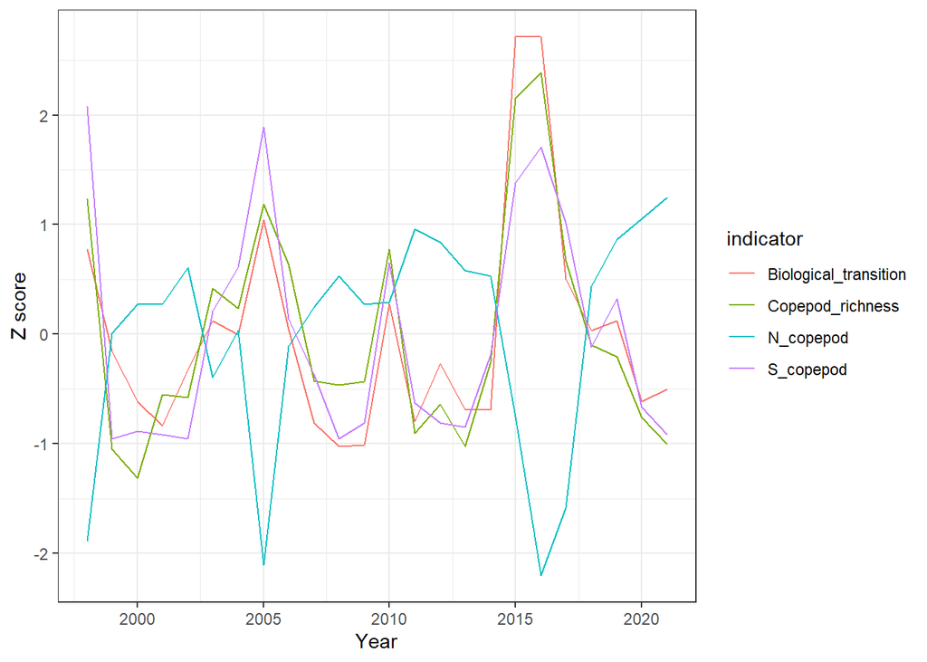

```r
cop.dat<-stoplight[9:12,]
cop.row<-cop.dat[,1]
cop.dat<-cop.dat[,3:26]
rownames(cop.dat)<-cop.row

#look at the data over time
cop.t<-t(cop.dat)
rows <- gsub("X","", rownames(cop.t))
row.names(cop.t)<-rows
cop.df<-data.frame(cop.t)
cop.df$Year<-row.names(cop.df)

# to make this tidyr happy
cop.df.long = cop.df %>% pivot_longer(-Year, names_to="indicator", values_to = "value") %>%
  mutate(Year=as.numeric(Year))

cop.df.long %>% group_by(indicator) %>% mutate(value=scale(value)) %>%
  ggplot(aes(x=Year,y=value,color=indicator)) + geom_line() + theme_bw() + labs(y="Z score")
```

```r
library(janitor)
covar <- stoplight %>%
  filter(Ecosystem.Indicators %in%
    c('Copepod_richness','N_copepod','S_copepod',"Deep_temperature","SST", "PDO_DecMarch","Biological_transition"))%>%
  select(!Type)%>%
  t() %>%
  as_tibble %>%
  row_to_names(row_number = 1)%>%
  mutate_if(is.character, as.numeric)
covar$Year <- 1998:2021

# to make this tidyr happy
cv.df = covar %>% pivot_longer(-Year, names_to="variable", values_to="value") %>%
  # z scores
  group_by(variable) %>% mutate(z_score = scale(value)) %>% group_by(Year) %>%
  filter(variable %in% c("N_copepod","S_copepod","Copepod_richness","Biological_transition"))

# save this as the non z score version
big.df = cv.df %>%
  select(-z_score) %>%
  # repivot for data analysis
  pivot_wider(names_from="variable", values_from="value")

# save as z score version
big.df.z = cv.df %>%
  select(-value) %>%
  # repivot for data analysis
  pivot_wider(names_from="variable", values_from="z_score")
```

# Results

## Multivariate HMM - 1-3 states

Here we evaluate the data support for a multivariate HMM 1, 2, or 3 state model.

```r
# loop through a few states and compare AIC
set.seed(123)
AIC_tbl = data.frame(nstate=0, AIC=0)
fit_list = NULL
for (i in 1:3){
mod<-depmix(list(Copepod_richness ~ 1, N_copepod ~ 1, S_copepod ~ 1,Biological_transition ~ 1),
                nstates = i,
                family=list(gaussian(), gaussian(),gaussian(),gaussian()),
                data=big.df)
fitmod <- fit(mod)
fit_list[[i]] = fitmod
# Transition matrix
# summary(fitmod, which = "transition")
# AIC
AIC_tbl[i,"nstate"] = i
AIC_tbl[i,"AIC"] = AIC(fitmod)
}
```

```
## converged at iteration 1 with logLik: -214.936
## converged at iteration 9 with logLik: -160.1462
## converged at iteration 5 with logLik: -127.0371
```

```r
# do the same but with z scores
set.seed(123)
AIC_tbl_z = data.frame(nstate=0, AIC=0)
fit_list_z = NULL
for (i in 1:3){
mod<-depmix(list(Copepod_richness ~ 1, N_copepod ~ 1, S_copepod ~ 1,Biological_transition ~ 1),
                nstates = i,
                family=list(gaussian(), gaussian(),gaussian(),gaussian()),
                data=big.df.z)
fitmod <- fit(mod)
fit_list_z[[i]] = fitmod
# Transition matrix
# summary(fitmod, which = "transition")
# AIC
AIC_tbl_z[i,"nstate"] = i
AIC_tbl_z[i,"AIC"] = AIC(fitmod)
}
```

```
## converged at iteration 1 with logLik: -134.1752
## converged at iteration 9 with logLik: -79.38551
## converged at iteration 5 with logLik: -46.27637
```

```r
AIC_tbl
```

```
##   nstate      AIC
## 1      1 445.8719
## 2      2 358.2925
## 3      3 318.0742
```

```r
AIC_tbl_z
```

```
##   nstate      AIC
## 1      1 284.3505
## 2      2 196.7710
## 3      3 156.5527
```

2 states seem like the most reasonable. Though a 3rd state lowers the AIC, adding more states to an HMM usually lowers the AIC. We proceed with a 2 state HMM due to its interpretability (there are 2 states in the PDO fluctuation, our system of interest).

## HMM 2-State plots

```r
# compare HMM with raw data and z score data
# RAW DATA
#most probable states
prstates2 <- apply(posterior(fit_list[[2]]) [,c("S1", "S2")], 1, which.max)
```

```r
# plot(prstates2, type='b', xlab='Time', ylab='State')

#estimated data/fits
mu2 <- summary(fit_list[[2]])[,1]
```

```
## Initial state probabilities model
## pr1 pr2
##   0   1
##
## Transition matrix
##         toS1  toS2
## fromS1 0.782 0.218
## fromS2 0.446 0.554
##
## Response parameters
## Resp 1 : gaussian
## Resp 2 : gaussian
## Resp 3 : gaussian
## Resp 4 : gaussian
##     Re1.(Intercept) Re1.sd Re2.(Intercept) Re2.sd Re3.(Intercept) Re3.sd
## St1          -1.334  1.065           0.280  0.142          -0.146  0.101
## St2           4.030  2.227          -0.366  0.394           0.325  0.187
##     Re4.(Intercept) Re4.sd
## St1         102.265  27.54
## St2         219.239  81.85
```

```r
pred2 <- data.frame("year"=seq(min(big.df$Year), max(big.df$Year)), "fit" = mu2[prstates2])

# Z SCORE DATA
#most probable states
prstates2_z <- apply(posterior(fit_list_z[[2]]) [,c("S1", "S2")], 1, which.max)
```

```r
# plot(prstates2, type='b', xlab='Time', ylab='State')

#estimated data/fits
mu2_z <- summary(fit_list_z[[2]])[,1]
```

```
## Initial state probabilities model
## pr1 pr2
##   0   1
##
## Transition matrix
##         toS1  toS2
## fromS1 0.782 0.218
## fromS2 0.446 0.554
##
## Response parameters
## Resp 1 : gaussian
## Resp 2 : gaussian
## Resp 3 : gaussian
## Resp 4 : gaussian
##     Re1.(Intercept) Re1.sd Re2.(Intercept) Re2.sd Re3.(Intercept) Re3.sd
## St1          -0.649  0.341           0.581  0.338          -0.650  0.370
## St2           1.070  0.713          -0.958  0.937           1.072  0.683
##     Re4.(Intercept) Re4.sd
## St1          -0.548  0.342
## St2           0.904  1.016
```

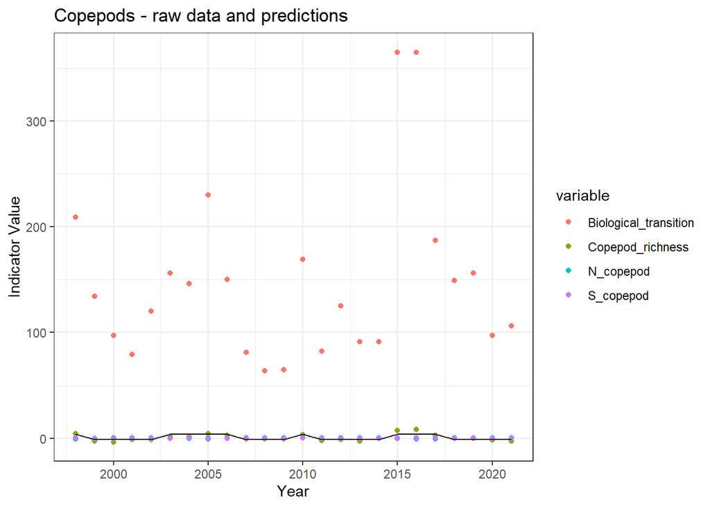

```r
pred2_z <- data.frame("year"=seq(min(big.df$Year), max(big.df$Year)), "fit" = mu2_z[prstates2_z])

# Raw data
ggplot() +
  geom_point(data=cv.df,aes(x=Year,y=value,color=variable)) +
  geom_line(data=pred2, aes(year, fit)) +
  ggtitle("Copepods - raw data and predictions") +
  ylab("Indicator Value") + xlab("Year") + theme_bw()
```

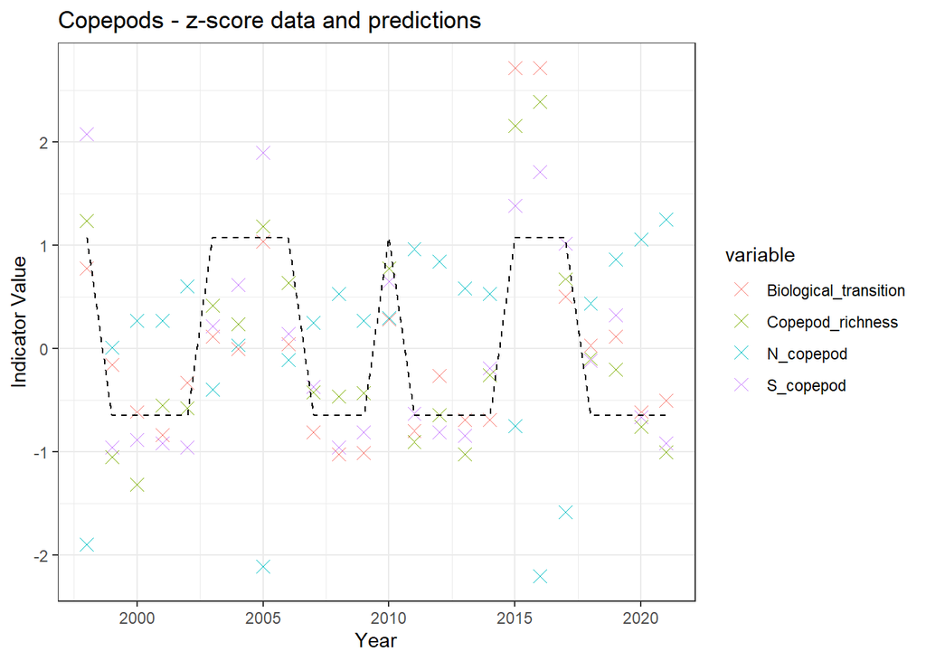

```r
# Z score
ggplot() +
  geom_point(data=cv.df,aes(x=Year,y=z_score,color=variable),shape=4,size=3) +
  geom_line(data=pred2_z, aes(year, fit), linetype = "dashed") +
  ggtitle("Copepods - z-score data and predictions") +
  ylab("Indicator Value") + xlab("Year") + theme_bw()
```

```r
# Transition Tables
summary(fit_list[[2]], which = "transition")
```

```
## Transition matrix
##         toS1  toS2
## fromS1 0.782 0.218
## fromS2 0.446 0.554
```

```r
summary(fit_list_z[[2]], which = "transition")
```

```
## Transition matrix
##         toS1  toS2
## fromS1 0.782 0.218
## fromS2 0.446 0.554
```

Here we test the data support for including SST and Deep temperature as covariates that *affect the transition probabilities* of our 2-state HMM model.

```r
#building the 2 state model
set.seed(123)
# model sel
cov.terms<-c("SST","Deep_temperature")
# Create a table of indicators as to whethr that predictor is included
mod.ind <- as.matrix(expand.grid(c(FALSE,TRUE),c(FALSE,TRUE)))
mod.tab <- data.frame(mod.ind)
names(mod.tab) <- cov.terms

# Define a column for storing AIC
mod.tab$AIC  <- NA
fit_covar_list = NULL
for (i in 1:nrow(mod.tab)){
  ind_on=as.matrix(mod.tab[i,1:length(cov.terms)])

  # Set which covariates should be included in formulas
  if (length(cov.terms[ind_on])==0){
    formula = ~1
  }else{
    formula =  paste("~",paste(cov.terms[ind_on],collapse="+"),sep="")
  }

  mod.2covar <-depmix(list(Copepod_richness ~ 1, N_copepod ~ 1, S_copepod ~ 1,Biological_transition ~ 1),
                nstates = 2,# Could change this to three. Adding states almost always improves AICs
                family=list(gaussian(), gaussian(),gaussian(),gaussian()),
                transition = eval(parse(text=formula)),## Affects the probability of transitioning
                data=covar)
  fit_covar_list[[i]]= fit(mod.2covar)

  mod.tab[i,"AIC"] = AIC((fit_covar_list[[i]]))
}
```

```
## converged at iteration 9 with logLik: -160.1462
## converged at iteration 5 with logLik: -157.8728
## converged at iteration 8 with logLik: -159.0089
## converged at iteration 7 with logLik: -153.9899
```

```r
mod.tab
```

```
##     SST Deep_temperature      AIC
## 1 FALSE            FALSE 358.2925
## 2  TRUE            FALSE 357.7455
## 3 FALSE             TRUE 360.0179
## 4  TRUE             TRUE 353.9798
```

Inclusion of both SST and Deep Temp as covariates for the transition matrix seems to improve the 2-state model.

## Effect of covariates

```r
convert_probs = function(fit, coef_value = 0) {
  # extract coefficients
  p1 <- fit@transition[[1]]@parameters$coefficients
  p2 <- fit@transition[[2]]@parameters$coefficients

  # assemble transition matrix in mlogit space
  m <- matrix(0, 2, 2)
  m[1,] <- p1[1,] + p1[2,] * coef_value
  m[2,] <- p2[1,] + p2[2,] * coef_value

  # exponentiate
  m <- exp(m)

  # normalize
  m[1,] <- m[1,] / sum(m[1,])
  m[2,] <- m[2,] / sum(m[2,])
  return(m)
}
```

Checking out the covariate effects separately.

```r
SST_mod <- fit_covar_list[[2]]
#summary(SST_mod)

SST_mod@transition
```

```
## [[1]]
## Model of type multinomial (mlogit), formula: ~SST
## Coefficients:
##             St1       St2
## (Intercept)   0 62.299316
## SST           0 -4.599023
## Probalities at zero values of the covariates.
## 8.785182e-28 1
##
## [[2]]
## Model of type multinomial (mlogit), formula: ~SST
## Coefficients:
##             St1        St2
## (Intercept)   0  5.7093173
## SST           0 -0.3275636
## Probalities at zero values of the covariates.
## 0.003303982 0.996696
```

```r
convert_probs(SST_mod, coef_value = 0)
```

```
##              [,1]     [,2]
## [1,] 8.785182e-28 1.000000
## [2,] 3.303982e-03 0.996696
```

```r
convert_probs(SST_mod, coef_value = 1)
```

```
##              [,1]      [,2]
## [1,] 8.731344e-26 1.0000000
## [2,] 4.578688e-03 0.9954213
```

```r
DT_mod <- fit_covar_list[[3]]
#summary(DT_mod)

DT_mod@transition
```

```
## [[1]]
## Model of type multinomial (mlogit), formula: ~Deep_temperature
## Coefficients:
##                  St1       St2
## (Intercept)        0 -24.24479
## Deep_temperature   0   2.78945
## Probalities at zero values of the covariates.
## 1 2.955431e-11
##
## [[2]]
## Model of type multinomial (mlogit), formula: ~Deep_temperature
## Coefficients:
##                  St1       St2
## (Intercept)        0 35.136158
## Deep_temperature   0 -4.392846
## Probalities at zero values of the covariates.
## 5.502504e-16 1
```

```r
convert_probs(DT_mod, coef_value = 0)
```

```
##              [,1]         [,2]
## [1,] 1.000000e+00 2.955431e-11
## [2,] 5.502504e-16 1.000000e+00
```

```r
convert_probs(DT_mod, coef_value = 1)
```

```
##              [,1]         [,2]
## [1,] 1.000000e+00 4.809097e-10
## [2,] 4.449887e-14 1.000000e+00
```

Deep temperature has a positive effect on the transition probabilites.

## Inspecting the best model

```r
summary(fit_covar_list[[4]])
```

```
## Initial state probabilities model
## pr1 pr2
##   1   0
##
## Transition model for state (component) 1
## Model of type multinomial (mlogit), formula: ~SST + Deep_temperature
## Coefficients:
##                  St1       St2
## (Intercept)        0  123.1808
## SST                0 -104.5494
## Deep_temperature   0  161.8354
## Probalities at zero values of the covariates.
## 3.186137e-54 1
##
## Transition model for state (component) 2
## Model of type multinomial (mlogit), formula: ~SST + Deep_temperature
## Coefficients:
##                  St1         St2
## (Intercept)        0  5.54345018
## SST                0 -0.33007916
## Deep_temperature   0  0.02560386
## Probalities at zero values of the covariates.
## 0.003897751 0.9961022
##
##
## Response parameters
## Resp 1 : gaussian
## Resp 2 : gaussian
## Resp 3 : gaussian
## Resp 4 : gaussian
##     Re1.(Intercept) Re1.sd Re2.(Intercept) Re2.sd Re3.(Intercept) Re3.sd
## St1           4.056  2.211          -0.371  0.391           0.327  0.187
## St2          -1.329  1.067           0.281  0.142          -0.145  0.102
##     Re4.(Intercept) Re4.sd
## St1         219.667 81.944
## St2         102.467 27.677
```

```r
#most probable states
prstates_covar <- apply(posterior(fit_covar_list[[4]]) [,c("S1", "S2")], 1, which.max)
```

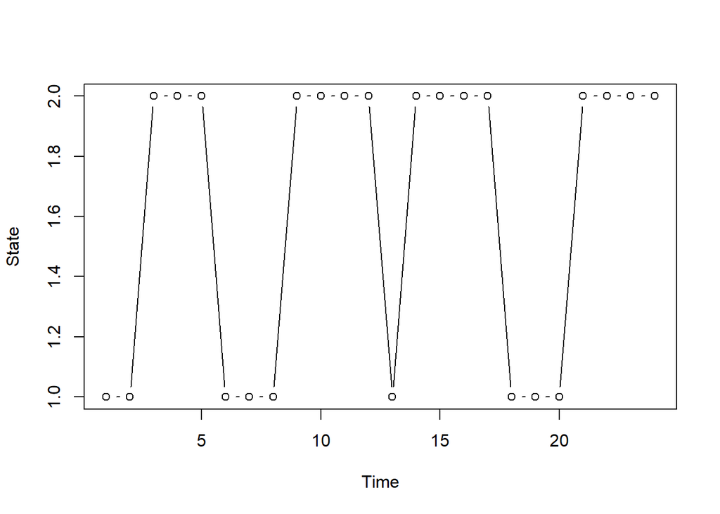

```r
plot(prstates_covar, type='b', xlab='Time', ylab='State')
```

```r
#estimated data
mu_covar <- summary(fit_covar_list[[4]])[,1]
```

```
## Initial state probabilities model
## pr1 pr2
##   1   0
##
## Transition model for state (component) 1
## Model of type multinomial (mlogit), formula: ~SST + Deep_temperature
## Coefficients:
##                  St1       St2
## (Intercept)        0  123.1808
## SST                0 -104.5494
## Deep_temperature   0  161.8354
## Probalities at zero values of the covariates.
## 3.186137e-54 1
##
## Transition model for state (component) 2
## Model of type multinomial (mlogit), formula: ~SST + Deep_temperature
## Coefficients:
##                  St1         St2
## (Intercept)        0  5.54345018
## SST                0 -0.33007916
## Deep_temperature   0  0.02560386
## Probalities at zero values of the covariates.
## 0.003897751 0.9961022
##
##
## Response parameters
## Resp 1 : gaussian
## Resp 2 : gaussian
## Resp 3 : gaussian
## Resp 4 : gaussian
##     Re1.(Intercept) Re1.sd Re2.(Intercept) Re2.sd Re3.(Intercept) Re3.sd
## St1           4.056  2.211          -0.371  0.391           0.327  0.187
## St2          -1.329  1.067           0.281  0.142          -0.145  0.102
##     Re4.(Intercept) Re4.sd
## St1         219.667 81.944
## St2         102.467 27.677
```

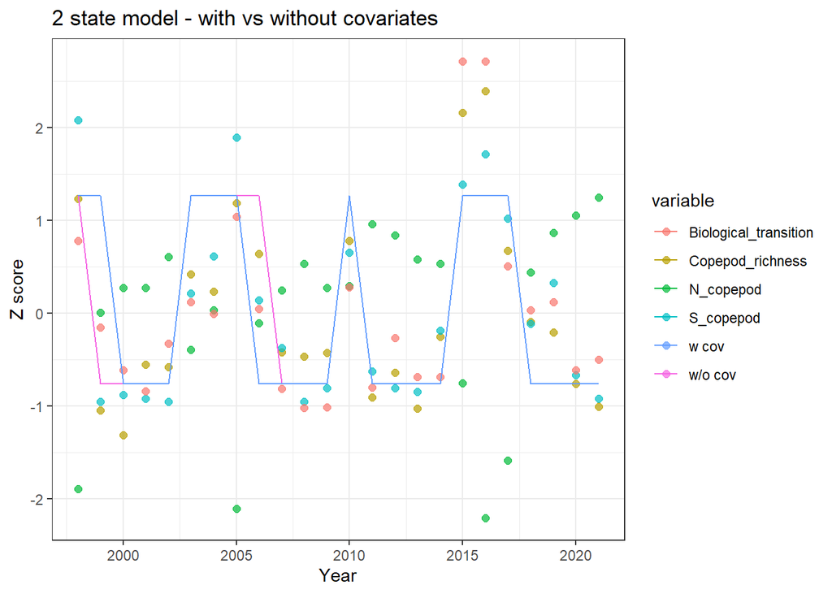

```r
pred_covar <- data.frame("year"=seq(min(covar$Year), max(covar$Year)), "fit" = mu_covar[prstates_covar])

ggplot(covar) +
  geom_point(data=cv.df,aes(x=Year,y=z_score,color=variable),size=2,alpha=0.7) +
  geom_line(data=pred2, aes(year, scale(fit),color="w/o cov"))+
  geom_line(data=pred_covar, aes(year, scale(fit),color="w cov")) +
  ggtitle("2 state model - with vs without covariates") +
  ylab("Z score") + xlab("Year") + theme_bw()
```

```r
## Fits almost the same with and without covariates
```

Adding covariates only slightly changes the fits of states, but since the AIC is decreased by < 10 it may not be worth including the covariates in the final model. The transition from state 1 to 2 only differ by 1 year around 1998 and 2006.

# Discussion

Temperature covariates seem to be minmally important in explaining the state transitions. However, if covariates are included, warmer temperatures are generally associated with increased copepod diversity.

# Team contributions

All team members contributed to experimental design and planning. ETS did the first draft of the 2- and 3- state HMMs and provided feedback and editing of the other team members’ work. Liz wrote the initial code to include the effect of covariates on the transition probabilities. Terrance improved and cleaned up code, and created the for loops for model selection. (Terrance feel free to add to/change this). All members edited and contributed to writing the Methods, Results and Discussions sections.